# Data Science Immersive: Data Visualization

## 2.5 Adjusting aesthetics using the scales functions

Before we move onto the other layers the last key thing you should know about the first three essential layers is how to adjust the scales. This is done using one of the scales functions. Like the geom functions, there is an intuitive naming convention. All the scale functions follow the form `scale_*_*()`.

The first `*` refers to which scale you want to modify, e.g.:

- `scale_x_*()`
- `scale_y_*()`
- `scale_color_*()`
  - Also `scale_colour_*()`
- `scale_fill_*()`
- `scale_shape_*()`
- `scale_linetype_*()`
- `scale_size_*()`

This **must** match the aesthetics that you’re actually using in the plot, or nothing will happen.

The second `*` refers to which *type* of scale to use, e.g.:

- **`scale_x_continuous()`**
- **`scale_y_continuous()`**
- **`scale_color_discrete()`**
  - also, `scale_colour_discrete()`

In our scatterplot we have three aesthetics, X, Y and color. Let’s take at how to use these functions one at a time. Here’s our starting point:

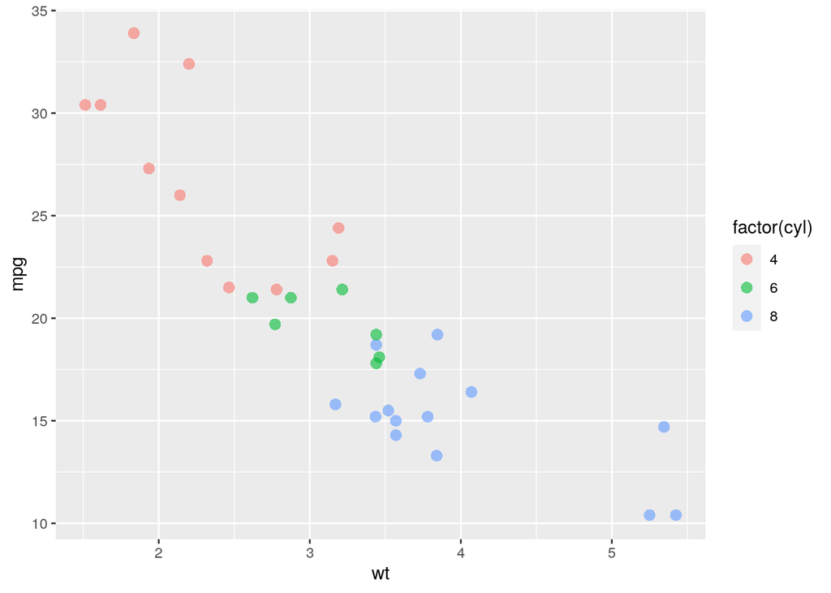

```r
# Base layers
p <- ggplot(mtcars, aes(wt, mpg, col = factor(cyl))) +
  geom_point(shape = 16, alpha = 0.6, size = 3)

p
```

Update colour scale, manual:

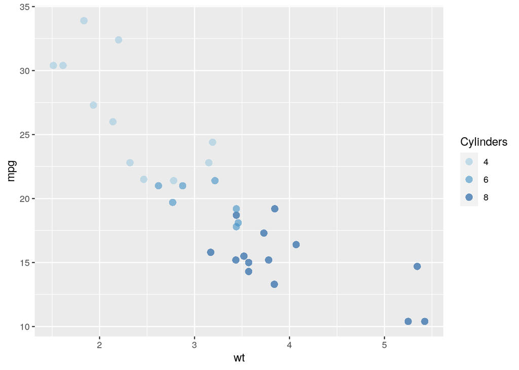

```r
# Scales (i.e. aesthetics)
p <- p +
  scale_colour_manual("Cylinders", values = myBlues)

p
```

Noticed that the first argument is the name that we want applied to that scale. In this case we also use the values function to add the colour palette that we defined in the previous section.

Update X axis, continuous:

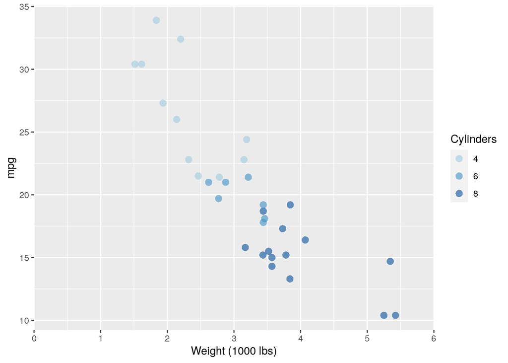

```r
p <- p +
  scale_x_continuous("Weight (1000 lbs)", limits = c(0,6), breaks = 0:6, expand = c(0,0))
p
```

The `limits` argument defines the scale’s range, `breaks` defines where to place the major tick marks, and `expand` is a two-element long numeric vector specifying the *additive* and *multiplicative* padding at the end of the axes. The default setting here is 5% extra room of the entire scale. The reason for this is that if you have a data point directly on the scale, and you don’t have the buffering, then it could be obscured by the axis. If you’re sure that you don’t need buffering, it’s fine to remove it.

Update Y axis, continuous:

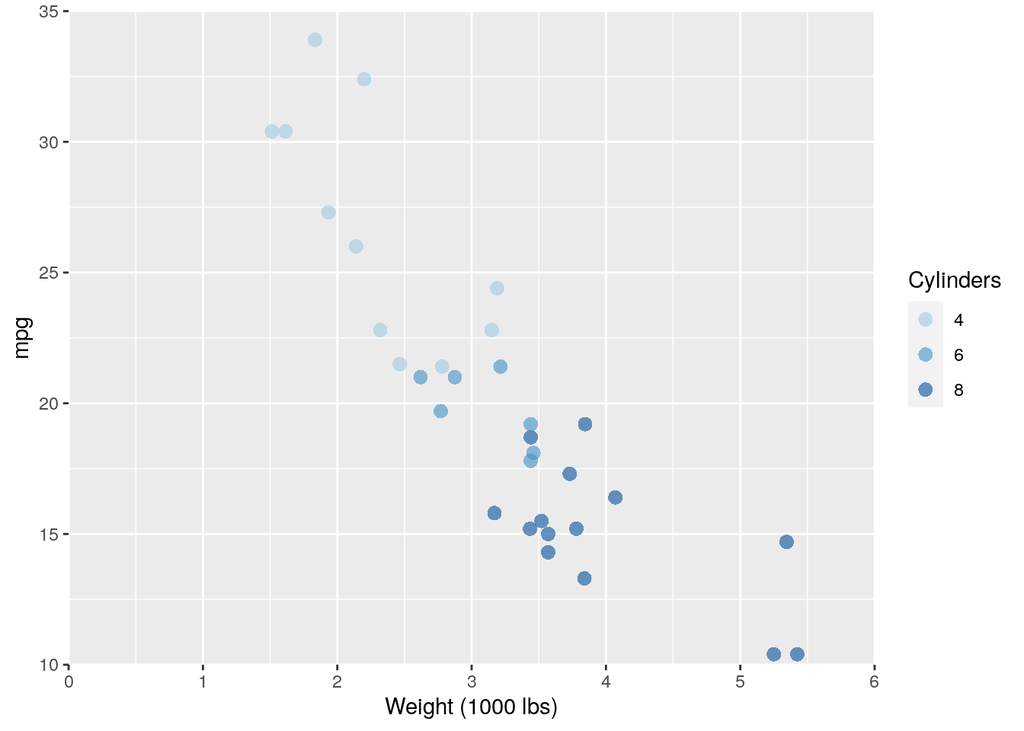

```r
# Scales (i.e. aesthetics)
p <- p +
  scale_y_continuous("mpg", limits = c(10,35), expand = c(0,0))
p
```

Of course you can do this all in one step, I broke it apart above so you can see each piece.

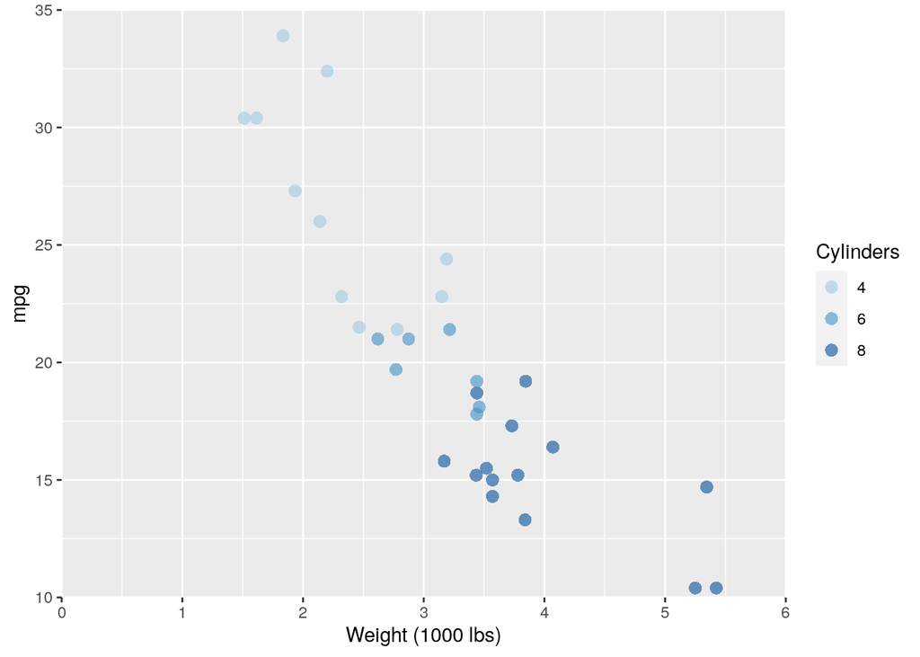

```r
ggplot(mtcars, aes(wt, mpg, col = factor(cyl))) +
  geom_point(shape = 16, alpha = 0.6, size = 3) +
  scale_colour_manual("Cylinders", values = myBlues) +
  scale_x_continuous("Weight (1000 lbs)", limits = c(0,6), breaks = 0:6, expand = c(0,0)) +
  scale_y_continuous("mpg", limits = c(10,35), expand = c(0,0))
```

Notice that the way our plotting commands are built means we can comment out a specific line if we don’t need it.

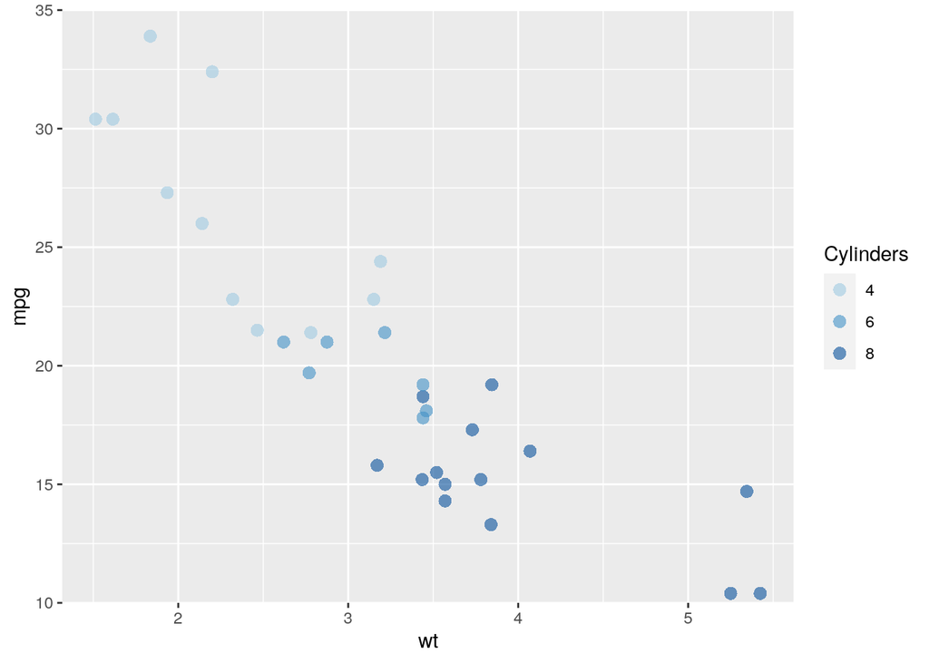

```r
ggplot(mtcars, aes(wt, mpg, col = factor(cyl))) +
  geom_point(shape = 16, alpha = 0.6, size = 3) +
  scale_colour_manual("Cylinders", values = myBlues) +
  # scale_x_continuous("Weight (1000 lbs)", limits = c(0,6), breaks = 0:6, expand = c(0,0)) +
  scale_y_continuous("mpg", limits = c(10,35), expand = c(0,0))
```

This won’t work if it’s the last line that we want to comment out. We’d have a hanging `+`, which would indicate to R that our command is not complete. So, if you feel that you want to experiment and comment out certain commands, you can end your ggplot call with `NULL`.

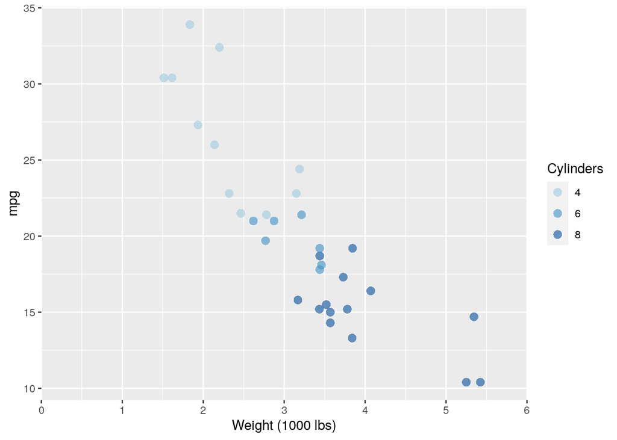

```r
ggplot(mtcars, aes(wt, mpg, col = factor(cyl))) +
  geom_point(shape = 16, alpha = 0.6, size = 3) +
  scale_colour_manual("Cylinders", values = myBlues) +
  scale_x_continuous("Weight (1000 lbs)", limits = c(0,6), breaks = 0:6, expand = c(0,0)) +
  # scale_y_continuous("mpg", limits = c(10,35), expand = c(0,0)) +
  NULL
```

You may be tempted to copy and paste code layers between plots, but be very cautious with copying and pasting scale functions! If you apply a limit to a data set, you may remove data that’s actually interesting just look at. Always plot the three essential layers *without* modifying the scales, then apply these functions to clean up your plot.

# 3 ggplot2: The optional 4 layers

Let’s take a look at the last four layers.

## 3.1 Layer 4: Statistics

We’ll look at applying two very common statistics to your plots in this layer.

### 3.1.1 Smoothing lines

We can add a LOESS curve, which is a non-parametric model, using:

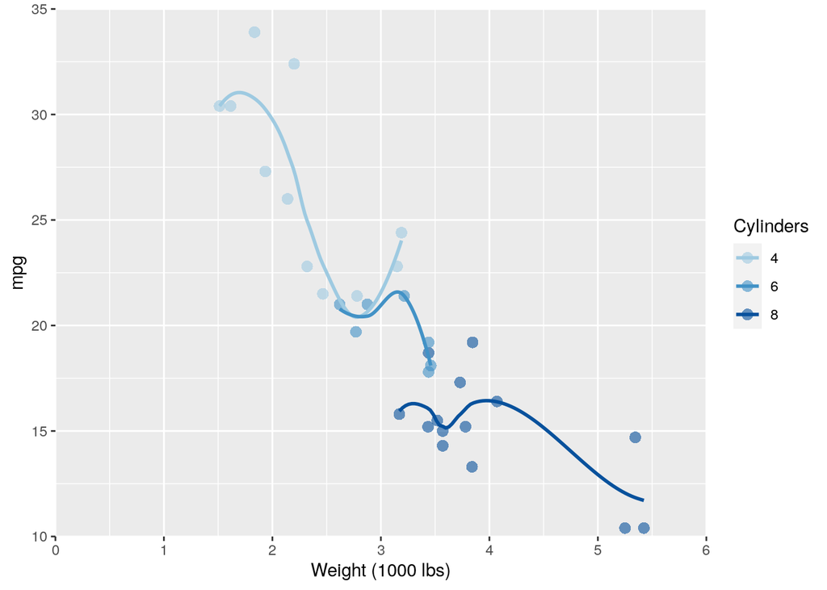

```r
p +
  stat_smooth(se = FALSE) # LOESS, default
```

The `se` argument specifies whether we want to plot the *95% Confidence Interval* or not.

We can plot a classic OLS model by specifying the `method`:

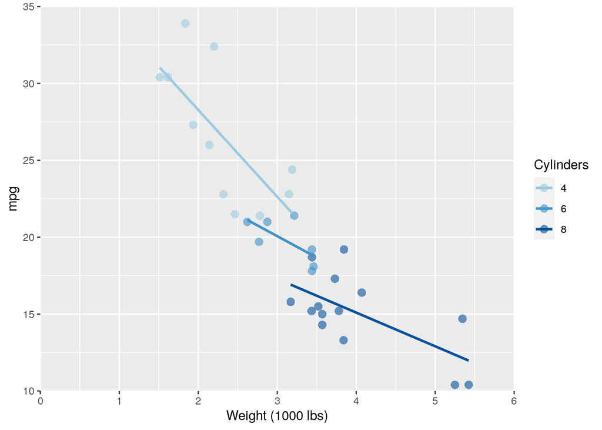

```r
# Add an OLS linear model
p + stat_smooth(method = "lm", se = FALSE) # Linear Model
```

Notice that because we have a `color` aesthetic, models are applied to each group separately. The reason for this is that there is an invisible aesthetic, called `group`, which inherits group identity from `color`. We can override the `group` aesthetic by defining it as a *dummy* variable, e.g. `1`, within the stats layer. Thus, we can color the points according to one variable, but apply the model to *all* the data.

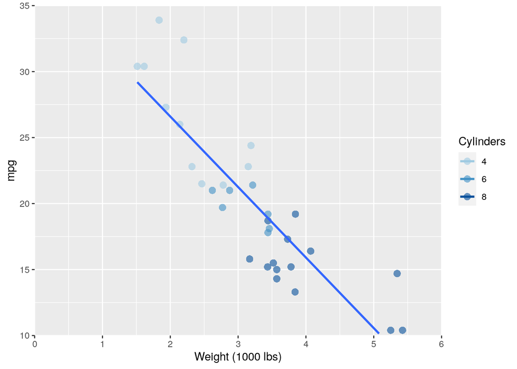

```r
# override the col/group aes:
p + stat_smooth(aes(group = 1), method = "lm", se = FALSE) # one group
```